# R-Graphics tool: part I

## lines

- The value `NA` is not connected with any points so that we can disconnect the line by using `NA`.

```r
plot(0,0, type = 'n', xlim = c(-2,2), ylim = c(-2,2))
x = c(-2, 1, NA, 1, 0)
y = c(0, -1, NA, -2, 1)
lines(x,y)
```

## lines

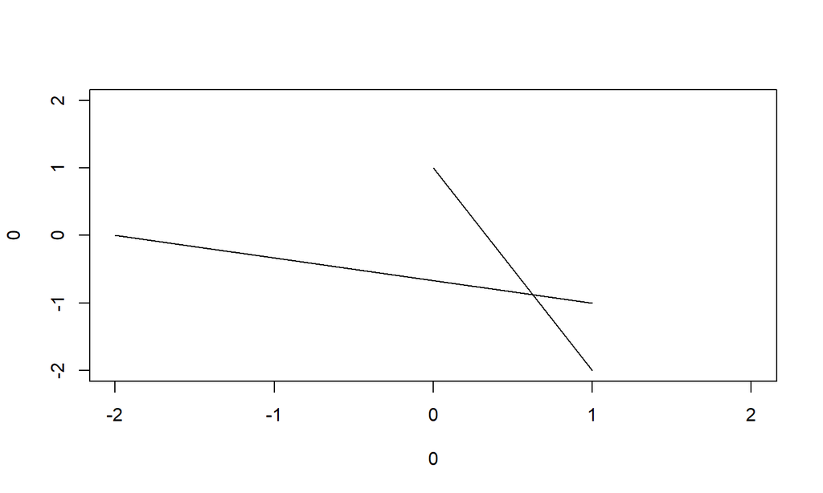

## lines

### options

- `lty`: line type

```r
plot(0,0, type = 'n', xlim = c(-2,2), ylim = c(-2,2))
x = c(-2, 1, NA, 1, 0)
y = c(0, -1, NA, -2, 1)
lines(x,y, lty = 2)
```

## lines

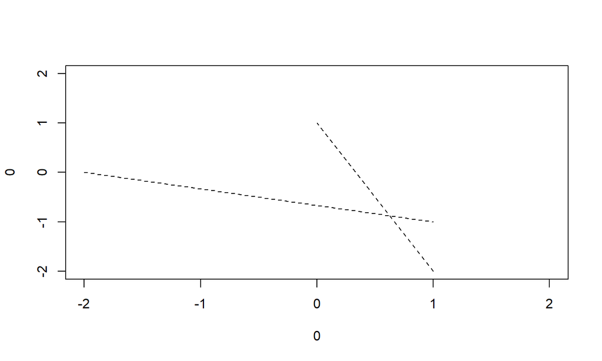

```r
plot(0,0, type = 'n', xlim = c(-2,2), ylim = c(-2,2))
x = c(-2, 1, NA, 1, 0)
y = c(0, -1, NA, -2, 1)
lines(x,y, lty = 2)
```

## lines

### exercise

- Explain the following code.

```r
plot(0,0, type = 'n', xlim = c(1,5), ylim = c(0,2))
x = seq(1,5, by = 1)
abline(v = x, lty = 1:length(x))
```

## legend

- `legend()` adds a legend on exsiting plot. ### arguments
- x: position on x, y: position on y (these can be replaced by shortcuts such as "bottomleft" )
- legedn: generally character vector
- color, pch, lty…

```r
z = sort(rnorm(100))
y1 = 2+ x + rnorm(100)
plot(z, y1, col = "blue", pch = 3)
points(z, y1/2, col = "red", pch = 19)
legend("topright", c("pch_3", "pch_19"), col = c("blue", "red"),
       pch = c(3,19))
```

## legend

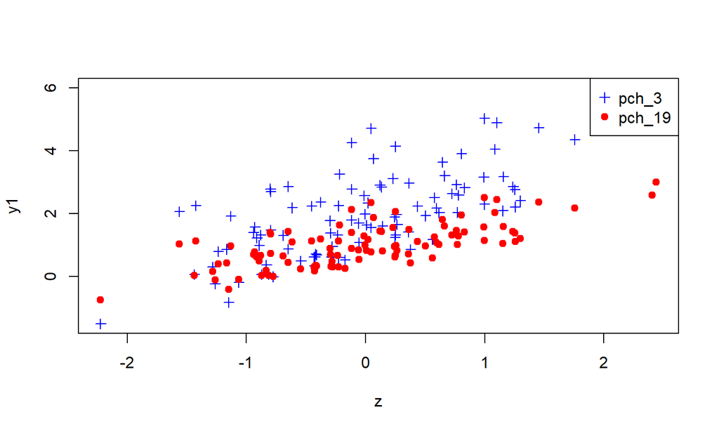

## legend

### Exercise

- Add the legend on the 'bottomright'

## Graphic parameter: par()

## par()

- par() set numerous graphical parameters in R. The function controls the layout of figure, the title, symbol of point and so on.

### frequently used parameter options

- `par(mfrow = c(2,1))`: \(2\times 1\) layout
- `par(cex = 1.2)`: set the character expansion be 1.2 (1.2 times larger)
- `par(bg = 'gray90')`: set the color of backgroupd by `gray90`
- `par(las = 2)`: set the text on axis be orthogoal to the axis.
- `par( mai = c(1,2,3,4))`: from the bottom clockwisely, set the margin be 1,2,3,and 4.

Se the document by `?par`

## par()

```r
par (mfrow = c(2,2), bg = 'gray50', col = 'white',
     col.main = 'lightblue', col.axis = 'yellow',
     col.lab = 'lightgreen')
x = rnorm(100)
y = 2+2*x + rnorm(100)
plot(x,y, main = "plot (x-y)-1", pch = 20)
y = 2+x + rnorm(100)
plot(x,y/2, main = "plot (x-y)-2")
y = 2+x + rnorm(100)
plot(x,y/3, main = "plot (x-y)-3", col.main = 'black')
y = 2+x + rnorm(100)
plot(x,y/4, main = "plot (x-y)-4", col.axis = 'white')
```

## par()

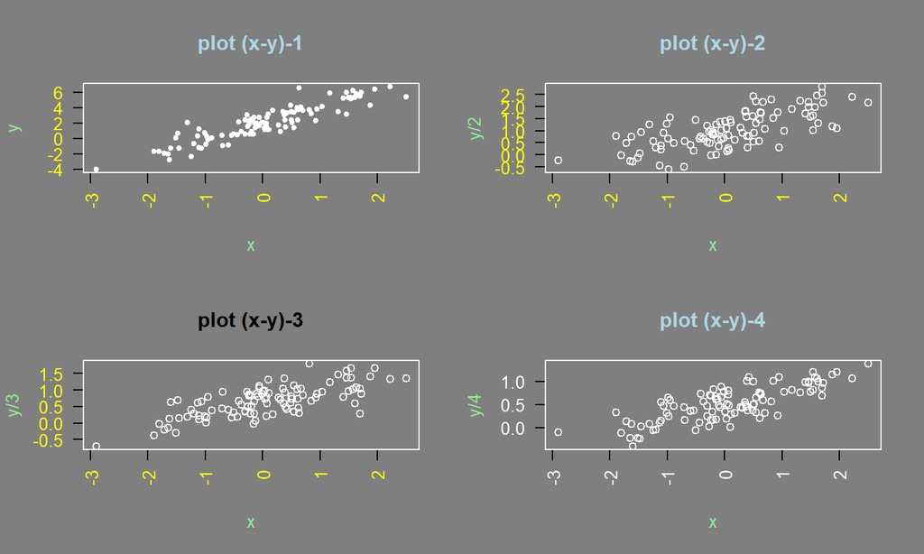